# Yield Curve Inversion

2017-10-31T21:28:43-05:00

The inverted yield curve has a reputation as being a strong predictor of recessions and its presence is often met with a level of panic.

The yield curve’s presence as a harbinger of recession can be doubted: an idea we hope to explore.

Using US data from the FRED database, we will explore this doubt surrounding yield curve inversion.

First, we use the `tidyquant` package to download monthly rates for different durations.

```r
# Get a list of FRED codes for US rates and US yield curve; choose monthly frequency
# to see, eg., the 3-month T-bill https://fred.stlouisfed.org/series/TB3MS
tickers <- c('TB3MS', # 3-month Treasury bill (or T-bill)
             'TB6MS', # 6-month
             'GS1',   # 1-year
             'GS2',   # 2-year, etc....
             'GS3',
             'GS5',
             'GS7',
             'GS10',
             'GS20',
             'GS30')  #.... all the way to the 30-year rate

# Turn  FRED codes to human readable variables
myvars <- c('3-Month Treasury Bill',
            '6-Month Treasury Bill',
            '1-Year Treasury Rate',
            '2-Year Treasury Rate',
            '3-Year Treasury Rate',
            '5-Year Treasury Rate',
            '7-Year Treasury Rate',
            '10-Year Treasury Rate',
            '20-Year Treasury Rate',
            '30-Year Treasury Rate')

maturity <- c('3m', '6m', '1y', '2y','3y','5y','7y','10y','20y','30y')

# by default R will sort these maturities alphabetically; but since we want
# to keep them in that exact order, we recast maturity as a factor
# or categorical variable, with the levels defined as we want
maturity <- factor(maturity, levels = maturity)

#We recast myvars to a factor for later facet use.
myvars <- factor(myvars, levels=myvars)

# Create a lookup dataset
mylookup<-data.frame(symbol=tickers,var=myvars, maturity=maturity)
# Take a look:
mylookup %>%
  knitr::kable()
```

| symbol | var | maturity |
| --- | --- | --- |
| TB3MS | 3-Month Treasury Bill | 3m |
| TB6MS | 6-Month Treasury Bill | 6m |
| GS1 | 1-Year Treasury Rate | 1y |
| GS2 | 2-Year Treasury Rate | 2y |
| GS3 | 3-Year Treasury Rate | 3y |
| GS5 | 5-Year Treasury Rate | 5y |
| GS7 | 7-Year Treasury Rate | 7y |
| GS10 | 10-Year Treasury Rate | 10y |
| GS20 | 20-Year Treasury Rate | 20y |
| GS30 | 30-Year Treasury Rate | 30y |

```r
df <- tickers %>% tidyquant::tq_get(get="economic.data",
                   from="1960-01-01")   # start from January 1960

glimpse(df)
```

```
## Rows: 6,774
## Columns: 3
## $ symbol <chr> "TB3MS", "TB3MS", "TB3MS", "TB3MS", "TB3MS", "TB3MS", "TB3MS",…
## $ date   <date> 1960-01-01, 1960-02-01, 1960-03-01, 1960-04-01, 1960-05-01, 1…
## $ price  <dbl> 4.35, 3.96, 3.31, 3.23, 3.29, 2.46, 2.30, 2.30, 2.48, 2.30, 2.…
```

Our dataframe `df` has three columns (variables):

- `symbol`: the FRED database ticker symbol
- `date`: already a date object
- `price`: the actual yield on that date

The first thing would be to join this dataframe `df` with the dataframe `mylookup` so we have a more readable version of maturities, durations, etc.

```r
#Join the two dataframes to creae a new dataframe called yield_curve.
yield_curve <-left_join(df,mylookup,by="symbol")
```

## Plotting the yield curve

### Yields on US rates by duration since 1960

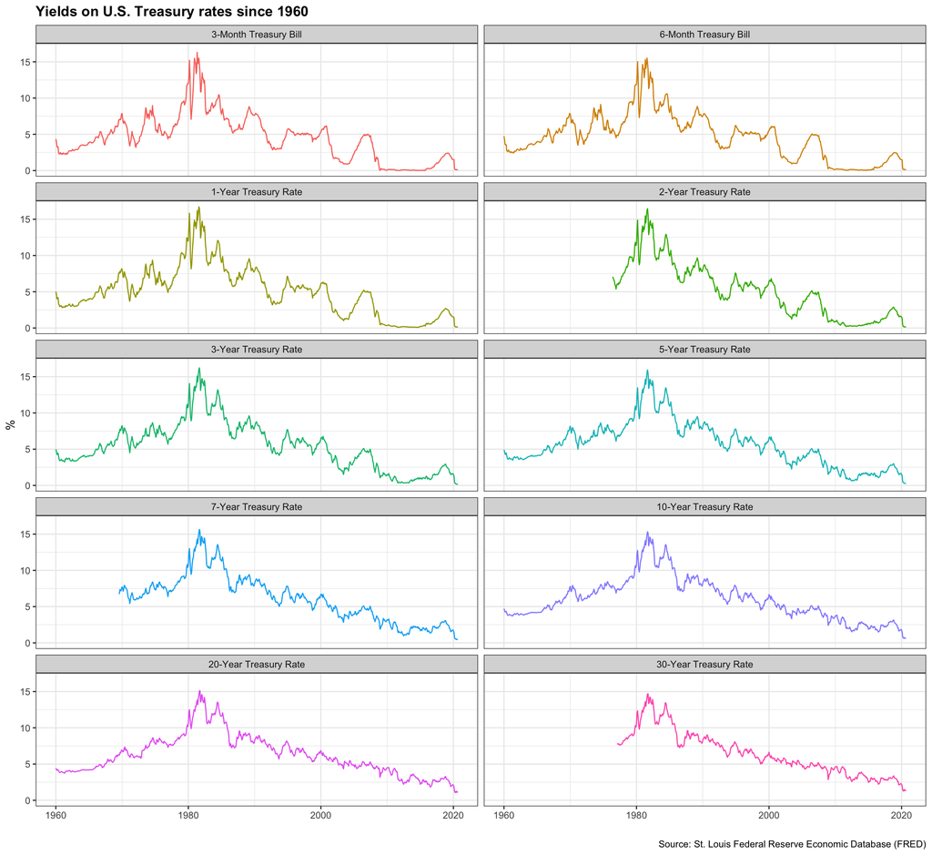

```r
ggplot(yield_curve, aes(x = date,
                        y = price,
                        color = maturity)) +
    facet_wrap(~var, ncol=2) +
    geom_line() +
    theme_bw() +
    theme(legend.position = "none") +
    labs(title = 'Yields on U.S. Treasury rates since 1960',
         caption = "Source: St. Louis Federal Reserve Economic Database (FRED)",
         x = "",
         y = '%')+
    theme(plot.title = element_text(face = "bold"))
```

### Monthly yields on US rates by duration since 1999 on a year-by-year basis

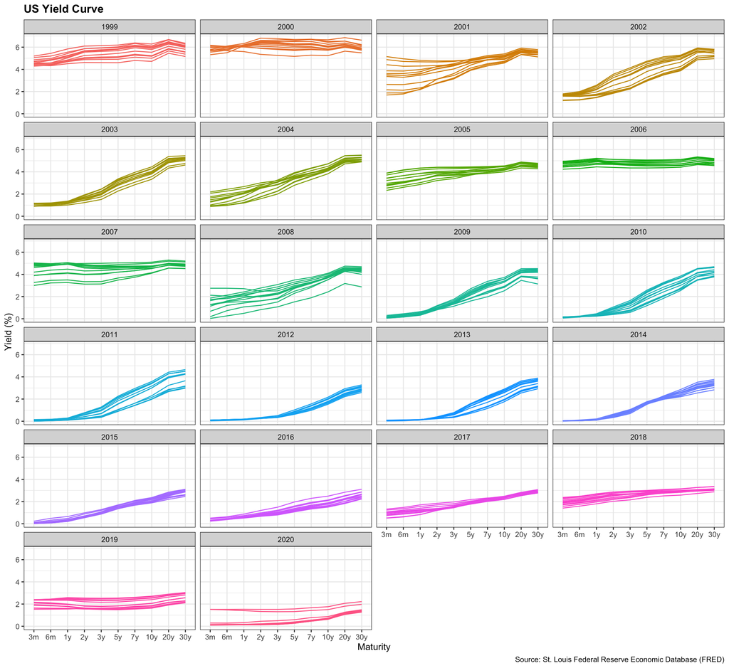

```r
new_yield_curve <- yield_curve %>%
  mutate(Year = year(date), Month = month(date)) %>%
  filter(Year >= 1999) %>%
  mutate(Year = as.factor(Year))


ggplot(new_yield_curve, aes(x = maturity,
                        y = price,
                        color= Year)) +
    facet_wrap(~Year, ncol=4) +
    geom_line(aes(group = Month)) +
    theme_bw() +
    theme(legend.position = "none") +
    labs(title = 'US Yield Curve',
         caption = "Source: St. Louis Federal Reserve Economic Database (FRED)",
         x = "Maturity",
         y = 'Yield (%)')+
    theme(plot.title = element_text(face = "bold"))
```

### 3-month and 10-year yields since 1999

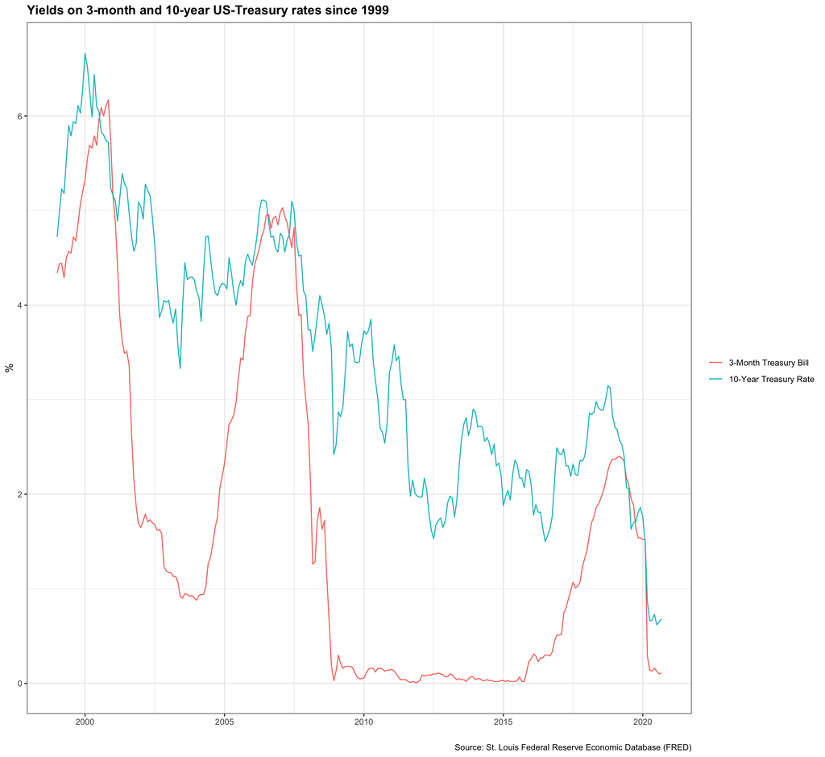

```r
diff_yield_curve <- new_yield_curve %>%
  filter(var %in% c("3-Month Treasury Bill", "10-Year Treasury Rate")) %>%
  group_by(var)


ggplot(diff_yield_curve, aes(x = date,
                        y = price)) +
    geom_line(aes(group = var, color = var)) +
    theme_bw() +
    theme(legend.title = element_blank())+
    labs(title = 'Yields on 3-month and 10-year US-Treasury rates since 1999',
         caption = "Source: St. Louis Federal Reserve Economic Database (FRED)",
         x = "",
         y = '%')+
    theme(plot.title = element_text(face = "bold"))
```

According to [Wikipedia’s list of recession in the United States](https://en.wikipedia.org/wiki/List_of_recessions_in_the_United_States), since 1999 there have been two recession in the US: between Mar 2001–Nov 2001 and between Dec 2007–June 2009. Does the yield curve seem to flatten before these recessions? Can a yield curve flattening really mean a recession is coming in the US? Since 1999, when did short-term (3 months) yield more than longer term (10 years) debt?

Besides calculating the spread (10year - 3months), there are a few things we need to do to produce our final plot

```r
# get US recession dates after 1946 from Wikipedia
# https://en.wikipedia.org/wiki/List_of_recessions_in_the_United_States

recessions <- tibble(
  from = c("1960-04-01", "1969-12-01", "1973-11-01", "1980-01-01","1981-07-01", "1990-07-01", "2001-03-01", "2007-12-01"),
  to = c( "1961-02-01", "1970-11-01", "1975-03-01", "1980-07-01", "1982-11-01", "1991-03-01", "2001-11-01", "2009-06-01")
  )  %>%
  mutate(From = ymd(from),
         To=ymd(to),
         duration_days = To-From)

recessions
```

```
## # A tibble: 8 x 5
##   from       to         From       To         duration_days
##   <chr>      <chr>      <date>     <date>     <drtn>
## 1 1960-04-01 1961-02-01 1960-04-01 1961-02-01 306 days
## 2 1969-12-01 1970-11-01 1969-12-01 1970-11-01 335 days
## 3 1973-11-01 1975-03-01 1973-11-01 1975-03-01 485 days
## 4 1980-01-01 1980-07-01 1980-01-01 1980-07-01 182 days
## 5 1981-07-01 1982-11-01 1981-07-01 1982-11-01 488 days
## 6 1990-07-01 1991-03-01 1990-07-01 1991-03-01 243 days
## 7 2001-03-01 2001-11-01 2001-03-01 2001-11-01 245 days
## 8 2007-12-01 2009-06-01 2007-12-01 2009-06-01 548 days
```

```r
yield_curve_wide <- yield_curve %>%
select(date, symbol, price) %>%
pivot_wider(names_from = symbol, values_from = price) %>%
mutate(difference=GS10-TB3MS)
```

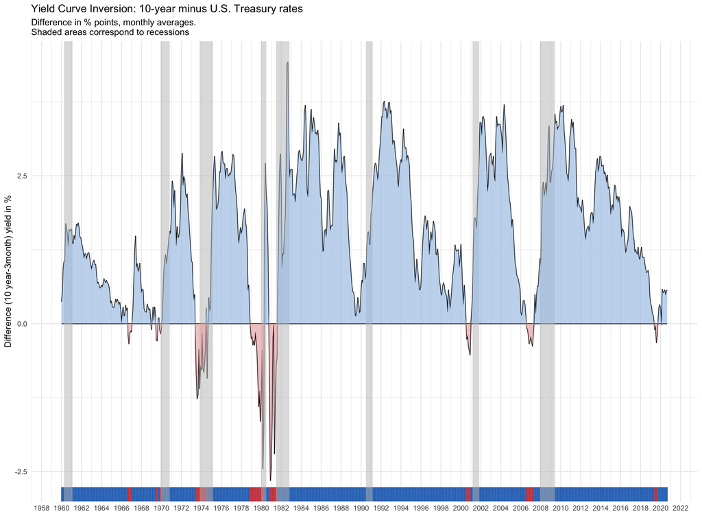

```r
library(scales)

yield_curve_wide %>%
ggplot(aes(x = date, y = difference))+
geom_line()+
geom_line(y=0)+
geom_rug(sides="b",
          colour=ifelse(yield_curve_wide$difference>0,"#2E74C0","#CB454A"))+
geom_rect(data=filter(recessions),
          inherit.aes=F,
          aes(xmin=From, xmax=To, ymin=-Inf, ymax=+Inf),
          fill='grey',
          alpha=0.5)+
scale_x_date(labels=date_format("%Y"), breaks=date_breaks("2 years"))+
theme_minimal()+
geom_ribbon(aes(ymin = pmin(difference,0),
                  ymax = 0),
                  fill = alpha("#EAB5B7",0.7)) +
  geom_ribbon(aes(ymin = 0,
                  ymax = pmax(difference,0)),
                  fill = alpha("#ACC8E7",0.7))+
  labs(title="Yield Curve Inversion: 10-year minus U.S. Treasury rates",
       subtitle = "Difference in % points, monthly averages.\nShaded areas correspond to recessions",
       x="",
       y="Difference (10 year-3month) yield in %")
```

As can be seen, the yield curve inversion in almost all cases predicts a recession. However, it must be maintained that it cannot be used as a 100% accuracte indicator and instead should be used as a strong indicator to support other research.